# 3 Logistic regression

## Setup

First let’s load the needed packages and some custom functions.

```r
# Packages
pacman::p_load(tidyverse, GGally, patchwork, ggfortify)

## Defining some custom functions
# Colors
# colorpair <- c("orangered", "dodgerblue")
# color_gender <- \ () {scale_color_manual(values = colorpair)}
# fill_gender <- \ () {scale_fill_manual(values = colorpair)}

# Dark mode theme
theme_darkmode <- \ (backg = "#141415") {
  ggdark::dark_theme_gray() %+replace%
    ggplot2::theme(
      plot.background = element_rect(color = backg, fill = backg),
      legend.box.background = element_rect(fill = backg, color = backg),
      legend.background = element_rect(fill = backg, color = backg),
      panel.grid = element_line(color = "gray20")
    )
}
```

## 3.2 Get data

```r
# Read data
datasets <- list.files("data/alc/ready", full.names = T)
newest <- datasets %>% sub('.*_', '', .) %>% as.Date() %>% max()
data <- datasets[grepl(newest, datasets)] %>%
  readr::read_csv(show_col_types = F)

# Glance at the data
# glimpse(data)
finalfit::finalfit_glimpse(data)$Continuous %>% select(-label) %>% knitr::kable()
```

|  | var_type | n | missing_n | missing_percent | mean | sd | min | quartile_25 | median | quartile_75 | max |
| --- | --- | --- | --- | --- | --- | --- | --- | --- | --- | --- | --- |
| age |  | 370 | 0 | 0.0 | 16.6 | 1.2 | 15.0 | 16.0 | 17.0 | 17.0 | 22.0 |
| Medu |  | 370 | 0 | 0.0 | 2.8 | 1.1 | 0.0 | 2.0 | 3.0 | 4.0 | 4.0 |
| Fedu |  | 370 | 0 | 0.0 | 2.6 | 1.1 | 0.0 | 2.0 | 3.0 | 3.8 | 4.0 |
| traveltime |  | 370 | 0 | 0.0 | 1.4 | 0.7 | 1.0 | 1.0 | 1.0 | 2.0 | 4.0 |
| studytime |  | 370 | 0 | 0.0 | 2.0 | 0.8 | 1.0 | 1.0 | 2.0 | 2.0 | 4.0 |
| famrel |  | 370 | 0 | 0.0 | 3.9 | 0.9 | 1.0 | 4.0 | 4.0 | 5.0 | 5.0 |
| freetime |  | 370 | 0 | 0.0 | 3.2 | 1.0 | 1.0 | 3.0 | 3.0 | 4.0 | 5.0 |
| goout |  | 370 | 0 | 0.0 | 3.1 | 1.1 | 1.0 | 2.0 | 3.0 | 4.0 | 5.0 |
| Dalc |  | 370 | 0 | 0.0 | 1.5 | 0.9 | 1.0 | 1.0 | 1.0 | 2.0 | 5.0 |
| Walc |  | 370 | 0 | 0.0 | 2.3 | 1.3 | 1.0 | 1.0 | 2.0 | 3.0 | 5.0 |
| health |  | 370 | 0 | 0.0 | 3.6 | 1.4 | 1.0 | 3.0 | 4.0 | 5.0 | 5.0 |
| failures |  | 370 | 0 | 0.0 | 0.2 | 0.6 | 0.0 | 0.0 | 0.0 | 0.0 | 3.0 |
| absences |  | 370 | 0 | 0.0 | 4.5 | 5.5 | 0.0 | 1.0 | 3.0 | 6.0 | 45.0 |
| G1 |  | 370 | 0 | 0.0 | 11.5 | 2.7 | 2.0 | 10.0 | 12.0 | 14.0 | 18.0 |
| G2 |  | 370 | 0 | 0.0 | 11.5 | 2.8 | 4.0 | 10.0 | 12.0 | 14.0 | 18.0 |
| G3 |  | 370 | 0 | 0.0 | 11.5 | 3.3 | 0.0 | 10.0 | 12.0 | 14.0 | 18.0 |
| alc_use |  | 370 | 0 | 0.0 | 1.9 | 1.0 | 1.0 | 1.0 | 1.5 | 2.5 | 5.0 |

## Description

The `Student Performance` data used for the assignment is from the open [UC Irvine Machine Learning Repository](https://archive.ics.uci.edu/dataset/320/student+performance). Briefly, the data describe student performance in secondary education of two Portuguese schools. Variables include student grades, demographic, social and school related features, based on questionnaire results. The data were processed by computing grades as average performance in two distinct subjects: Mathematics (mat) and Portuguese language (por). More metadata of the two original datasets can be found from `data/alc/docs/student.txt`.

## 3.3 Hypotheses

### Instructions

> – choose 4 interesting variables in the data and for each of them, present your personal hypothesis about their relationships with alcohol consumption.

I’ll choose the following variables and list each corresponding hypothesis after the variable:

1. `traveltime` **home to school travel time** *(numeric: 1 - <15 min., 2 - 15 to 30 min., 3 - 30 min. to 1 hour, or 4 - >1 hour)*

$H_1:$ Location, location, location… Students that live in an urban setting (where the school is) might have easier access to bar and subsequent alcohol use.

2. `studytime` **weekly study time** *(numeric: 1 - <2 hours, 2 - 2 to 5 hours, 3 - 5 to 10 hours, or 4 - >10 hours)*

$H_1:$ Students that use a lot of alcohol may prioritize drinking in favor of studying. Students that put a lot of effort into studies may be inclined to use less alcohol.

3. `failures` - **number of past class failures** *(numeric: n if 1<=n<3, else 4)*

$H_1:$ It is plausible that alcohol use impairs cognitive abilities. Poor success in studies, indicated by failing tests and courses could be a sign of alcohol abuse.

4. `romantic`: **with a romantic relationship** *(binary: yes or no)*

$H_1:$ It is well-known that couples have healthier diet than singles - perhaps this also applies to the fourth macronutrient: alcohol.

## 3.4 Distributions

[figure not shown]

```r
# Variables and their value labs
vars_hypo <- tribble(
  ~var, ~labs,
  "traveltime", c("<15 min.", "15 to 30 min.", "30 min. to 1 hour", ">1 hour"),
  "studytime", c("<2 hours", "2 to 5 hours", "5 to 10 hours", ">10 hours"),
  "failures", c("n=0", "n=1", "n=2", "n=3"),
  "romantic", c("Taken", "Single")
)

# Plot in a loop
plist <- lapply(1:nrow(vars_hypo), \ (i) {
  p <- data %>%
    mutate(
      !!vars_hypo$var[[i]] := factor(
        .data[[vars_hypo$var[[i]]]],
        labels = vars_hypo$labs[[i]]
      )
    ) %>%
    ggplot(aes(x = .data[[vars_hypo$var[[i]]]]))
  p <- p + geom_bar(aes(fill = .data[[vars_hypo$var[[i]]]]))
  p <- p + theme(
    axis.text.x = element_text(angle = 45, hjust = 1, vjust = 1),
    legend.position = "none"
  )
  p <- p + harrypotter::scale_fill_hp_d("LunaLovegood")
  p
})

ggpubr::ggarrange(
  plotlist = plist,
  align = "hv"
)
```

Data are ordinal but not interval, and also heavily skewed. Let’s use Spearman correlation coefficient, which is a non-parametric test that works for (at least) ordinal data.

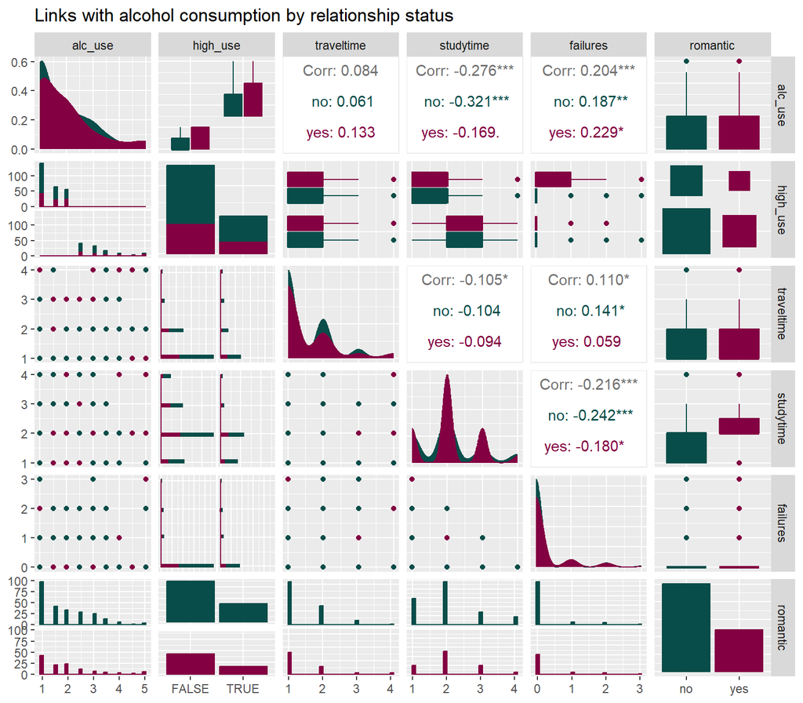

```r
# Plot
data[, c("alc_use", "high_use", vars_hypo$var)] %>%
  GGally::ggpairs(
    mapping = aes(color = romantic, fill = romantic), #, alpha = .3
    upper = list(continuous = wrap("cor", method = "spearman")),
  ) +
  harrypotter::scale_color_hp_d("LunaLovegood") +
  harrypotter::scale_fill_hp_d("LunaLovegood") +
  ggtitle("Links with alcohol consumption by relationship status")
```

**Interpretation:** We can see that alcohol use is related to lower `studytime` ($r = -0.276$) and higher rate of `failures` ($r = 0.204$), but spearman correlation analysis reveals no significant link with `traveltime` ($r = 0.084$). The inverse relationship between alcohol use and `studytime` may depend on `romantic` status, as a strong, significant correlation coefficient is seen only in single students ($r = -0.321$).

```r
# Variables
response <- "high_use"
predictors <- vars_hypo$var
form <- as.formula(paste0(response, " ~ ", paste(predictors, collapse = " + ")))

# Fit the model
m1 <- glm(formula = form, data = data)
m1_s <- summary(m1)
m1_s
```

```
##
## Call:
## glm(formula = form, data = data)
##
## Deviance Residuals:
##     Min       1Q   Median       3Q      Max
## -0.7727  -0.3221  -0.2293   0.5075   0.9569
##
## Coefficients:
##             Estimate Std. Error t value Pr(>|t|)
## (Intercept)  0.38023    0.08283   4.590  6.1e-06 ***
## traveltime   0.06816    0.03321   2.052 0.040865 *
## studytime   -0.09312    0.02795  -3.331 0.000953 ***
## failures     0.11643    0.04261   2.732 0.006597 **
## romanticyes -0.03282    0.04934  -0.665 0.506412
## ---
## Signif. codes:  0 '***' 0.001 '**' 0.01 '*' 0.05 '.' 0.1 ' ' 1
##
## (Dispersion parameter for gaussian family taken to be 0.1959533)
##
##     Null deviance: 77.700  on 369  degrees of freedom
## Residual deviance: 71.523  on 365  degrees of freedom
## AIC: 453.93
##
## Number of Fisher Scoring iterations: 2
```

[figure not shown]

```r
# ORs and their CIs
CIs <- data.frame(
  OR = coef(m1) %>% exp(), # Odds ratios
  Lower = confint(m1)[, "2.5 %"] %>% exp(), # 95% CIs
  Upper = confint(m1)[, "97.5 %"] %>% exp(), # 95% CIs
  P = m1_s$coefficients[, "Pr(>|t|)"]
) %>% rownames_to_column(var = "Predictor")

# Plot estimates
p <- CIs %>%
  filter(Predictor != "(Intercept)") %>%
  ggplot(aes(x = OR, y = Predictor))
p <- p + geom_vline(xintercept = 1)
p <- p + geom_pointrange(aes(xmin = Lower, xmax = Upper), size = 1)
p <- p + geom_text(aes(
  label = paste0(gtsummary::style_pvalue(P, prepend_p = T), "\n\n")
))
p <- p + theme(
  panel.grid.major.y = element_blank(),
  panel.grid.minor.y = element_blank()
)
p <- p + scale_x_continuous(trans = "log2", breaks = c(.8, .9, 1, 1.1, 1.2))
p <- p + ggtitle("Forest plot") + xlab("OR for high alcohol use (95% CI)") + ylab("")
p
```